# Assessment2

Yuanyuan Peng* **s4666415

26/03/2022

### Load packages

```r
#install.packages("tidyverse")
#install.packages("knitr")
#install.packages("tidymodels")
#install.packages("modeldata")

library(tidyverse)
library(knitr)
library(skimr)
library(tidymodels)
library(modeldata)
library(dplyr)
```

### Dataset

Import data called thanksgiving_meals

```r
thanksgiving_meals <- read_csv('https://raw.githubusercontent.com/rfordatascience/tidytuesday/master/data/2018/2018-11-20/thanksgiving_meals.csv')
```

This dataset will be used below.

### Data Wrangling and visualization

### 1. Display the first 10 rows of the dataset using `kable()` function

```r
head(thanksgiving_meals,10)
```

```
## # A tibble: 10 × 65
##        id celebrate main_dish main_dish_other main_prep main_prep_other stuffing
##     <dbl> <chr>     <chr>     <chr>           <chr>     <chr>           <chr>
##  1 4.34e9 Yes       Turkey    <NA>            Baked     <NA>            Bread-b…
##  2 4.34e9 Yes       Turkey    <NA>            Baked     <NA>            Bread-b…
##  3 4.34e9 Yes       Turkey    <NA>            Roasted   <NA>            Rice-ba…
##  4 4.34e9 Yes       Turkey    <NA>            Baked     <NA>            Bread-b…
##  5 4.34e9 Yes       Tofurkey  <NA>            Baked     <NA>            Bread-b…
##  6 4.34e9 Yes       Turkey    <NA>            Roasted   <NA>            Rice-ba…
##  7 4.34e9 Yes       Turkey    <NA>            Baked     <NA>            Bread-b…
##  8 4.34e9 Yes       Turkey    <NA>            Baked     <NA>            Rice-ba…
##  9 4.34e9 Yes       Turkey    <NA>            Roasted   <NA>            Bread-b…
## 10 4.34e9 Yes       Other (p… Turkey and Ham  Baked     <NA>            Bread-b…
## # … with 58 more variables: stuffing_other <chr>, cranberry <chr>,
## #   cranberry_other <chr>, gravy <chr>, side1 <chr>, side2 <chr>, side3 <chr>,
## #   side4 <chr>, side5 <chr>, side6 <chr>, side7 <chr>, side8 <chr>,
## #   side9 <chr>, side10 <chr>, side11 <chr>, side12 <chr>, side13 <chr>,
## #   side14 <chr>, side15 <chr>, pie1 <chr>, pie2 <chr>, pie3 <chr>, pie4 <chr>,
## #   pie5 <chr>, pie6 <chr>, pie7 <chr>, pie8 <chr>, pie9 <chr>, pie10 <chr>,
## #   pie11 <chr>, pie12 <chr>, pie13 <chr>, dessert1 <chr>, dessert2 <chr>, …
```

### 2. Using `skim()` display the summary of variables.

```r
skim(thanksgiving_meals)
```

Data summary

| Name | thanksgiving_meals |
| --- | --- |
| Number of rows | 1058 |
| Number of columns | 65 |
| _______________________ |  |
| Column type frequency: |  |
| character | 64 |
| numeric | 1 |
| ________________________ |  |
| Group variables | None |

**Variable type: character**

| skim_variable | n_missing | complete_rate | min | max | empty | n_unique | whitespace |
| --- | --- | --- | --- | --- | --- | --- | --- |
| celebrate | 0 | 1.00 | 2 | 3 | 0 | 2 | 0 |
| main_dish | 84 | 0.92 | 6 | 22 | 0 | 8 | 0 |
| main_dish_other | 1023 | 0.03 | 4 | 85 | 0 | 32 | 0 |
| main_prep | 84 | 0.92 | 5 | 22 | 0 | 5 | 0 |
| main_prep_other | 1007 | 0.05 | 1 | 33 | 0 | 32 | 0 |
| stuffing | 84 | 0.92 | 4 | 22 | 0 | 4 | 0 |
| stuffing_other | 1022 | 0.03 | 4 | 46 | 0 | 29 | 0 |
| cranberry | 84 | 0.92 | 4 | 22 | 0 | 4 | 0 |
| cranberry_other | 1033 | 0.02 | 3 | 61 | 0 | 24 | 0 |
| gravy | 84 | 0.92 | 2 | 3 | 0 | 2 | 0 |
| side1 | 903 | 0.15 | 15 | 15 | 0 | 1 | 0 |
| side2 | 816 | 0.23 | 7 | 7 | 0 | 1 | 0 |
| side3 | 970 | 0.08 | 11 | 11 | 0 | 1 | 0 |
| side4 | 594 | 0.44 | 4 | 4 | 0 | 1 | 0 |
| side5 | 823 | 0.22 | 9 | 9 | 0 | 1 | 0 |
| side6 | 843 | 0.20 | 11 | 11 | 0 | 1 | 0 |
| side7 | 372 | 0.65 | 32 | 32 | 0 | 1 | 0 |
| side8 | 852 | 0.19 | 19 | 19 | 0 | 1 | 0 |
| side9 | 241 | 0.77 | 15 | 15 | 0 | 1 | 0 |
| side10 | 292 | 0.72 | 14 | 14 | 0 | 1 | 0 |
| side11 | 887 | 0.16 | 6 | 6 | 0 | 1 | 0 |
| side12 | 849 | 0.20 | 15 | 15 | 0 | 1 | 0 |
| side13 | 427 | 0.60 | 27 | 27 | 0 | 1 | 0 |
| side14 | 947 | 0.10 | 22 | 22 | 0 | 1 | 0 |
| side15 | 947 | 0.10 | 4 | 78 | 0 | 89 | 0 |
| pie1 | 544 | 0.49 | 5 | 5 | 0 | 1 | 0 |
| pie2 | 1023 | 0.03 | 10 | 10 | 0 | 1 | 0 |
| pie3 | 945 | 0.11 | 6 | 6 | 0 | 1 | 0 |
| pie4 | 925 | 0.13 | 9 | 9 | 0 | 1 | 0 |
| pie5 | 1022 | 0.03 | 13 | 13 | 0 | 1 | 0 |
| pie6 | 1019 | 0.04 | 8 | 8 | 0 | 1 | 0 |
| pie7 | 1024 | 0.03 | 5 | 5 | 0 | 1 | 0 |
| pie8 | 716 | 0.32 | 5 | 5 | 0 | 1 | 0 |
| pie9 | 329 | 0.69 | 7 | 7 | 0 | 1 | 0 |
| pie10 | 906 | 0.14 | 12 | 12 | 0 | 1 | 0 |
| pie11 | 1018 | 0.04 | 4 | 4 | 0 | 1 | 0 |
| pie12 | 987 | 0.07 | 22 | 22 | 0 | 1 | 0 |
| pie13 | 987 | 0.07 | 5 | 46 | 0 | 61 | 0 |
| dessert1 | 948 | 0.10 | 13 | 13 | 0 | 1 | 0 |
| dessert2 | 1042 | 0.02 | 8 | 8 | 0 | 1 | 0 |
| dessert3 | 930 | 0.12 | 8 | 8 | 0 | 1 | 0 |
| dessert4 | 986 | 0.07 | 11 | 11 | 0 | 1 | 0 |
| dessert5 | 867 | 0.18 | 10 | 10 | 0 | 1 | 0 |
| dessert6 | 854 | 0.19 | 7 | 7 | 0 | 1 | 0 |
| dessert7 | 1015 | 0.04 | 5 | 5 | 0 | 1 | 0 |
| dessert8 | 792 | 0.25 | 9 | 9 | 0 | 1 | 0 |
| dessert9 | 955 | 0.10 | 13 | 13 | 0 | 1 | 0 |
| dessert10 | 763 | 0.28 | 4 | 4 | 0 | 1 | 0 |
| dessert11 | 924 | 0.13 | 22 | 22 | 0 | 1 | 0 |
| dessert12 | 924 | 0.13 | 3 | 59 | 0 | 92 | 0 |
| prayer | 99 | 0.91 | 2 | 3 | 0 | 2 | 0 |
| travel | 107 | 0.90 | 59 | 80 | 0 | 4 | 0 |
| watch_program | 556 | 0.47 | 13 | 13 | 0 | 1 | 0 |
| kids_table_age | 107 | 0.90 | 2 | 13 | 0 | 12 | 0 |
| hometown_friends | 107 | 0.90 | 2 | 3 | 0 | 2 | 0 |
| friendsgiving | 107 | 0.90 | 2 | 3 | 0 | 2 | 0 |
| black_friday | 107 | 0.90 | 2 | 3 | 0 | 2 | 0 |
| work_retail | 107 | 0.90 | 2 | 3 | 0 | 2 | 0 |
| work_black_friday | 988 | 0.07 | 2 | 13 | 0 | 3 | 0 |
| community_type | 110 | 0.90 | 5 | 8 | 0 | 3 | 0 |
| age | 33 | 0.97 | 3 | 7 | 0 | 4 | 0 |
| gender | 33 | 0.97 | 4 | 6 | 0 | 2 | 0 |
| family_income | 33 | 0.97 | 12 | 20 | 0 | 11 | 0 |
| us_region | 59 | 0.94 | 7 | 18 | 0 | 9 | 0 |

**Variable type: numeric**

| skim_variable | n_missing | complete_rate | mean | sd | p0 | p25 | p50 | p75 | p100 | hist |
| --- | --- | --- | --- | --- | --- | --- | --- | --- | --- | --- |
| id | 0 | 1 | 4336731188 | 493783.4 | 4335894916 | 4336339486 | 4336796628 | 4337012140 | 4337954960 | ▅▃▇▂▂ |

```r
# When I run the function of skim, it can be seen that most of variables are character. The character is qualitative variable. I think celebrate, stuffing and main dish may be useful. Because there is some problems for other value. The variables of side, pie and dessert exist  many missing value. It may affect the prediction to some extent.

# I think the stuffing, dressing and main dish may predict a community type or US_region. Because they reflect the preference on different kinds of food. Some people from close region may have similar preference. But lots of missing value are still big problem to affect the prediction.
```

### 3. Use `fct_reorder` and `parse_number` functions to create a factor variable `family_income`

```r
thanksgiving <- thanksgiving_meals %>%
  mutate(family_income = fct_reorder(family_income, parse_number(family_income)))
skim(thanksgiving)
```

Data summary

| Name | thanksgiving |
| --- | --- |
| Number of rows | 1058 |
| Number of columns | 65 |
| _______________________ |  |
| Column type frequency: |  |
| character | 63 |
| factor | 1 |
| numeric | 1 |
| ________________________ |  |
| Group variables | None |

**Variable type: character**

| skim_variable | n_missing | complete_rate | min | max | empty | n_unique | whitespace |
| --- | --- | --- | --- | --- | --- | --- | --- |
| celebrate | 0 | 1.00 | 2 | 3 | 0 | 2 | 0 |
| main_dish | 84 | 0.92 | 6 | 22 | 0 | 8 | 0 |
| main_dish_other | 1023 | 0.03 | 4 | 85 | 0 | 32 | 0 |
| main_prep | 84 | 0.92 | 5 | 22 | 0 | 5 | 0 |
| main_prep_other | 1007 | 0.05 | 1 | 33 | 0 | 32 | 0 |
| stuffing | 84 | 0.92 | 4 | 22 | 0 | 4 | 0 |
| stuffing_other | 1022 | 0.03 | 4 | 46 | 0 | 29 | 0 |
| cranberry | 84 | 0.92 | 4 | 22 | 0 | 4 | 0 |
| cranberry_other | 1033 | 0.02 | 3 | 61 | 0 | 24 | 0 |
| gravy | 84 | 0.92 | 2 | 3 | 0 | 2 | 0 |
| side1 | 903 | 0.15 | 15 | 15 | 0 | 1 | 0 |
| side2 | 816 | 0.23 | 7 | 7 | 0 | 1 | 0 |
| side3 | 970 | 0.08 | 11 | 11 | 0 | 1 | 0 |
| side4 | 594 | 0.44 | 4 | 4 | 0 | 1 | 0 |
| side5 | 823 | 0.22 | 9 | 9 | 0 | 1 | 0 |
| side6 | 843 | 0.20 | 11 | 11 | 0 | 1 | 0 |
| side7 | 372 | 0.65 | 32 | 32 | 0 | 1 | 0 |
| side8 | 852 | 0.19 | 19 | 19 | 0 | 1 | 0 |
| side9 | 241 | 0.77 | 15 | 15 | 0 | 1 | 0 |
| side10 | 292 | 0.72 | 14 | 14 | 0 | 1 | 0 |
| side11 | 887 | 0.16 | 6 | 6 | 0 | 1 | 0 |
| side12 | 849 | 0.20 | 15 | 15 | 0 | 1 | 0 |
| side13 | 427 | 0.60 | 27 | 27 | 0 | 1 | 0 |
| side14 | 947 | 0.10 | 22 | 22 | 0 | 1 | 0 |
| side15 | 947 | 0.10 | 4 | 78 | 0 | 89 | 0 |
| pie1 | 544 | 0.49 | 5 | 5 | 0 | 1 | 0 |
| pie2 | 1023 | 0.03 | 10 | 10 | 0 | 1 | 0 |
| pie3 | 945 | 0.11 | 6 | 6 | 0 | 1 | 0 |
| pie4 | 925 | 0.13 | 9 | 9 | 0 | 1 | 0 |
| pie5 | 1022 | 0.03 | 13 | 13 | 0 | 1 | 0 |
| pie6 | 1019 | 0.04 | 8 | 8 | 0 | 1 | 0 |
| pie7 | 1024 | 0.03 | 5 | 5 | 0 | 1 | 0 |
| pie8 | 716 | 0.32 | 5 | 5 | 0 | 1 | 0 |
| pie9 | 329 | 0.69 | 7 | 7 | 0 | 1 | 0 |
| pie10 | 906 | 0.14 | 12 | 12 | 0 | 1 | 0 |
| pie11 | 1018 | 0.04 | 4 | 4 | 0 | 1 | 0 |
| pie12 | 987 | 0.07 | 22 | 22 | 0 | 1 | 0 |
| pie13 | 987 | 0.07 | 5 | 46 | 0 | 61 | 0 |
| dessert1 | 948 | 0.10 | 13 | 13 | 0 | 1 | 0 |
| dessert2 | 1042 | 0.02 | 8 | 8 | 0 | 1 | 0 |
| dessert3 | 930 | 0.12 | 8 | 8 | 0 | 1 | 0 |
| dessert4 | 986 | 0.07 | 11 | 11 | 0 | 1 | 0 |
| dessert5 | 867 | 0.18 | 10 | 10 | 0 | 1 | 0 |
| dessert6 | 854 | 0.19 | 7 | 7 | 0 | 1 | 0 |
| dessert7 | 1015 | 0.04 | 5 | 5 | 0 | 1 | 0 |
| dessert8 | 792 | 0.25 | 9 | 9 | 0 | 1 | 0 |
| dessert9 | 955 | 0.10 | 13 | 13 | 0 | 1 | 0 |
| dessert10 | 763 | 0.28 | 4 | 4 | 0 | 1 | 0 |
| dessert11 | 924 | 0.13 | 22 | 22 | 0 | 1 | 0 |
| dessert12 | 924 | 0.13 | 3 | 59 | 0 | 92 | 0 |
| prayer | 99 | 0.91 | 2 | 3 | 0 | 2 | 0 |
| travel | 107 | 0.90 | 59 | 80 | 0 | 4 | 0 |
| watch_program | 556 | 0.47 | 13 | 13 | 0 | 1 | 0 |
| kids_table_age | 107 | 0.90 | 2 | 13 | 0 | 12 | 0 |
| hometown_friends | 107 | 0.90 | 2 | 3 | 0 | 2 | 0 |
| friendsgiving | 107 | 0.90 | 2 | 3 | 0 | 2 | 0 |
| black_friday | 107 | 0.90 | 2 | 3 | 0 | 2 | 0 |
| work_retail | 107 | 0.90 | 2 | 3 | 0 | 2 | 0 |
| work_black_friday | 988 | 0.07 | 2 | 13 | 0 | 3 | 0 |
| community_type | 110 | 0.90 | 5 | 8 | 0 | 3 | 0 |
| age | 33 | 0.97 | 3 | 7 | 0 | 4 | 0 |
| gender | 33 | 0.97 | 4 | 6 | 0 | 2 | 0 |
| us_region | 59 | 0.94 | 7 | 18 | 0 | 9 | 0 |

**Variable type: factor**

| skim_variable | n_missing | complete_rate | ordered | n_unique | top_counts |
| --- | --- | --- | --- | --- | --- |
| family_income | 33 | 0.97 | FALSE | 11 | $25: 180, Pre: 136, $50: 135, $75: 133 |

**Variable type: numeric**

| skim_variable | n_missing | complete_rate | mean | sd | p0 | p25 | p50 | p75 | p100 | hist |
| --- | --- | --- | --- | --- | --- | --- | --- | --- | --- | --- |
| id | 0 | 1 | 4336731188 | 493783.4 | 4335894916 | 4336339486 | 4336796628 | 4337012140 | 4337954960 | ▅▃▇▂▂ |

```r
summary(thanksgiving)
```

```
##        id             celebrate          main_dish         main_dish_other
##  Min.   :4.336e+09   Length:1058        Length:1058        Length:1058
##  1st Qu.:4.336e+09   Class :character   Class :character   Class :character
##  Median :4.337e+09   Mode  :character   Mode  :character   Mode  :character
##  Mean   :4.337e+09
##  3rd Qu.:4.337e+09
##  Max.   :4.338e+09
##
##   main_prep         main_prep_other      stuffing         stuffing_other
##  Length:1058        Length:1058        Length:1058        Length:1058
##  Class :character   Class :character   Class :character   Class :character
##  Mode  :character   Mode  :character   Mode  :character   Mode  :character
##
##
##
##
##   cranberry         cranberry_other       gravy              side1
##  Length:1058        Length:1058        Length:1058        Length:1058
##  Class :character   Class :character   Class :character   Class :character
##  Mode  :character   Mode  :character   Mode  :character   Mode  :character
##
##
##
##
##     side2              side3              side4              side5
##  Length:1058        Length:1058        Length:1058        Length:1058
##  Class :character   Class :character   Class :character   Class :character
##  Mode  :character   Mode  :character   Mode  :character   Mode  :character
##
##
##
##
##     side6              side7              side8              side9
##  Length:1058        Length:1058        Length:1058        Length:1058
##  Class :character   Class :character   Class :character   Class :character
##  Mode  :character   Mode  :character   Mode  :character   Mode  :character
##
##
##
##
```

[output cut: 81 more lines]

```
##  Length:1058        Length:1058        Length:1058
##  Class :character   Class :character   Class :character
##  Mode  :character   Mode  :character   Mode  :character
##
##
##
##
##               family_income  us_region
##  $25,000 to $49,999  :180   Length:1058
##  Prefer not to answer:136   Class :character
##  $50,000 to $74,999  :135   Mode  :character
##  $75,000 to $99,999  :133
##  $100,000 to $124,999:111
##  (Other)             :330
##  NA's                : 33
```

### 4. What is the number of people who celebrate?

```r
thanksgiving_meals %>%
  count(celebrate)
```

```
## # A tibble: 2 × 2
##   celebrate     n
##   <chr>     <int>
## 1 No           78
## 2 Yes         980
```

```r
#According to count function, it can be seen 980 people who celebrate.
```

### 5. What are categories and insights for each main dish served and the method it is prepared?

```r
thanksgiving_meals %>%
  count(main_dish, main_prep)
```

```
## # A tibble: 31 × 3
##    main_dish    main_prep                  n
##    <chr>        <chr>                  <int>
##  1 Chicken      Baked                      4
##  2 Chicken      Fried                      2
##  3 Chicken      Other (please specify)     2
##  4 Chicken      Roasted                    4
##  5 Ham/Pork     Baked                     22
##  6 Ham/Pork     I don't know               1
##  7 Ham/Pork     Other (please specify)     1
##  8 Ham/Pork     Roasted                    5
##  9 I don't know Fried                      1
## 10 I don't know I don't know               3
## # … with 21 more rows
```

### 6. Create 3 different data viz showing insights for main dish served and the method. Provide your own legend and use themes.

```r
#Filtering for missing data values
#It can be seen that there are many missing data valuesin main dish colume and main prep colume, so the first step I decide to filter missing data.

thanksgiving <- thanksgiving_meals %>%
  filter(!is.na(main_dish),
         !main_dish %in% c("I don't know")) %>%
  filter(!is.na(main_prep),
         !main_prep %in% c("I don't know"))
```

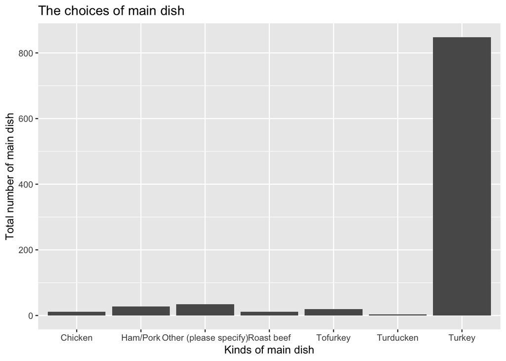

```r
#Dataviz 1
thanksgiving %>%
  ggplot(aes(main_dish)) +
  geom_bar() +
  labs(x = "Kinds of main dish", y = "Total number of main dish",
       title = "The choices of main dish")
```

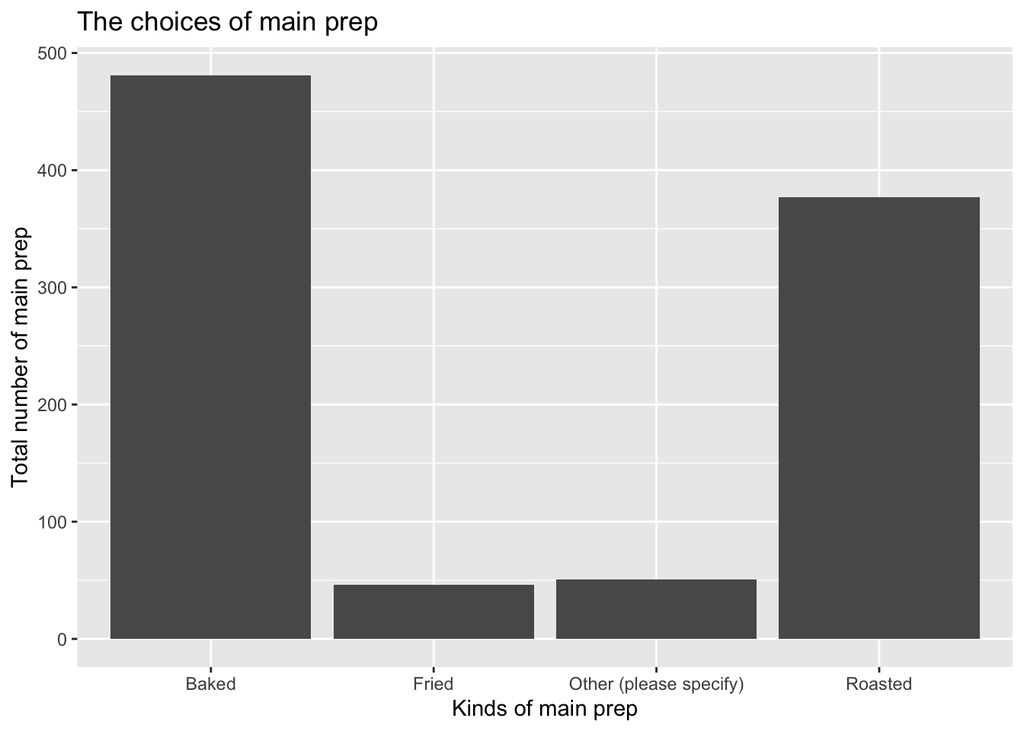

```r
#According to the bar chart, the most popular main dish is Turkey in thanksgiving meal.


thanksgiving %>%
  ggplot(aes(main_prep)) +
  geom_bar() +
  labs(x = "Kinds of main prep", y = "Total number of main prep",
       title = "The choices of main prep")
```

```r
#According to the bar chart, the most popular main method of cooking is baked in thanksgiving meal.
```

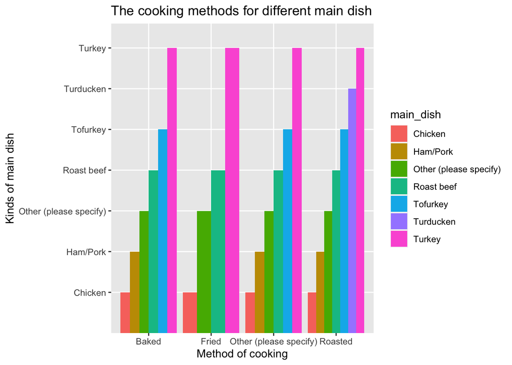

```r
#Dataviz 2
thanksgiving %>%
  ggplot(aes(main_prep, main_dish, fill= main_dish))+
  geom_col(position = "dodge") +
  labs(x = "Method of cooking", y = "Kinds of main dish",fill="main_dish",
       title = "The cooking methods for different main dish")
```

```r
#The method of roasted is used in all kinds of main dishes, while the method of fried is just used in four kinds of main dishes. And the Turducken is only cooked by roasted.
```

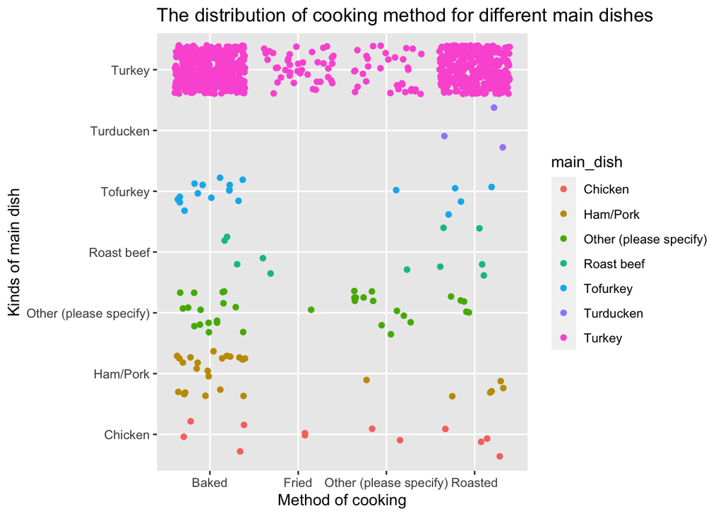

```r
#Datavia 3
thanksgiving %>%
  ggplot(aes(main_prep,main_dish,color= main_dish))+
  geom_jitter() +
  labs(x = "Method of cooking", y = "Kinds of main dish",fill="main_dish",
       title = "The distribution of cooking method for different main dishes")
```

```r
#Most of customers perfer to choosing baked and roasted for their main dishes. And turkey is most of choices by customers.
```

### 7. How many use cranberry sauce? How many use gravy?

```r
thanksgiving_cg <- thanksgiving_meals %>%
  filter(!is.na(cranberry),
         !cranberry %in% c("None"))
thanksgiving_cg %>%
  count(cranberry)
```

```
## # A tibble: 3 × 2
##   cranberry                  n
##   <chr>                  <int>
## 1 Canned                   502
## 2 Homemade                 301
## 3 Other (please specify)    25
```

```r
#The total number of cranberry sauce user is 828

thanksgiving_meals %>%
  count(gravy)
```

```
## # A tibble: 3 × 2
##   gravy     n
##   <chr> <int>
## 1 No       82
## 2 Yes     892
## 3 <NA>     84
```

```r
#The total number of gravy users is 892
```

### 8-9. What is the distribution of those who celebrate across income ranges. Create a data viz.

```r
#Filtering for missing data values and useless data
thanksgiving_income <- thanksgiving_meals %>%
  filter(!is.na(family_income),
         !family_income %in% c("Prefer not to answer"))
```

```r
#Reorder the level of family income
thanksgiving_income$family_income <- factor(thanksgiving_income$family_income, levels=c("$0 to $9,999","$10,000 to $24,999","$25,000 to $49,999","$50,000 to $74,999","$75,000 to $99,999", "$100,000 to $124,999","$125,000 to $149,999","$150,000 to $174,999","$175,000 to $199,999","$200,000 and up"))
```

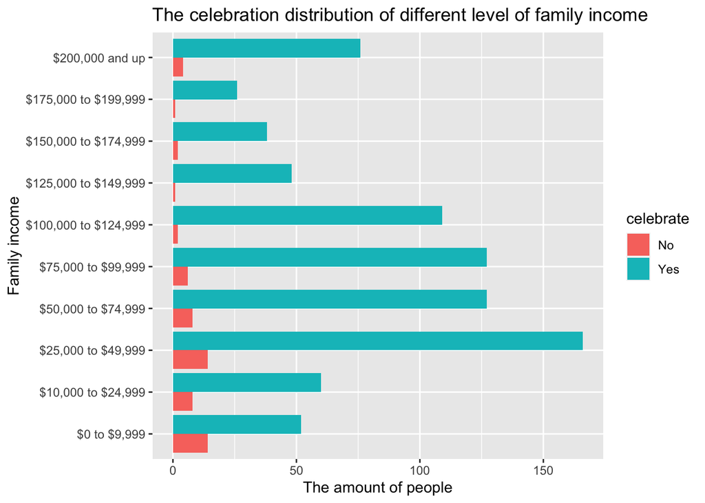

```r
#Making the bar chart
thanksgiving_income %>%
  arrange(family_income) %>%
  ggplot(aes(family_income, fill=celebrate)) +
  geom_bar(position = "dodge")+
  coord_flip() +
  labs(x = "Family income", y = "The amount of people",fill="celebrate",
       title = "The celebration distribution of different level of family income")
```

```r
#According to the bar chart, it can be seen that most of people prefer to celebrating who are in the medium levels of income. And people who don't want to celebrate roughly depends on income level. The amount of people who don't want to celebrate is increased by the income decreasing.
```

### 10. Use the following code to create a new data set 2 mark

Write 2-3 sentences with your explanation of what it does.

```r
thanksgiving_new <- thanksgiving_meals %>%
  select(id, starts_with("side"),
         starts_with("pie"),
         starts_with("dessert")) %>%
  select(-side15, -pie13, -dessert12) %>%
  gather(type, value, -id) %>%
  filter(!is.na(value),
         !value %in% c("None", "Other (please specify)")) %>%
  mutate(type = str_remove(type, "\\d+"))


# explanation : select id colume and colume that names begin with side, pie and dessert. The second step is to delect the colume called side15, pie13 and dessert12.The filter function delect the invaild value and value called none and other. The last step is to rename new varible of type, dividing into side, pie and dessert.
```

### 11-12. Intall package `widyr` and use `pairwise_cor()` function

```r
#install and load package

#install.packages("widyr")

library(widyr)
```

```r
thanksgiving_new %>%
  pairwise_cor(value, id, sort = TRUE)
```

```
## # A tibble: 992 × 3
##    item1               item2               correlation
##    <chr>               <chr>                     <dbl>
##  1 Cookies             Brownies                  0.411
##  2 Brownies            Cookies                   0.411
##  3 Sweet Potato        Macaroni and cheese       0.365
##  4 Macaroni and cheese Sweet Potato              0.365
##  5 Rolls/biscuits      Mashed potatoes           0.341
##  6 Mashed potatoes     Rolls/biscuits            0.341
##  7 Peach cobbler       Sweet Potato              0.339
##  8 Sweet Potato        Peach cobbler             0.339
##  9 Pumpkin             Mashed potatoes           0.290
## 10 Mashed potatoes     Pumpkin                   0.290
## # … with 982 more rows
```

```r
#It shows that correlations of pairs of items in a column. This step shows the correlation of different types of value.
```

### 13. Use `lm()` or randomForest() function to build a model that predict a family income based on data in the dataset.

```r
### 13. Use `lm()` or randomForest() function to build a model that predict a family income based on data in the dataset.

skim(thanksgiving)
```

Data summary

| Name | thanksgiving |
| --- | --- |
| Number of rows | 955 |
| Number of columns | 65 |
| _______________________ |  |
| Column type frequency: |  |
| character | 64 |
| numeric | 1 |
| ________________________ |  |
| Group variables | None |

**Variable type: character**

| skim_variable | n_missing | complete_rate | min | max | empty | n_unique | whitespace |
| --- | --- | --- | --- | --- | --- | --- | --- |
| celebrate | 0 | 1.00 | 3 | 3 | 0 | 1 | 0 |
| main_dish | 0 | 1.00 | 6 | 22 | 0 | 7 | 0 |
| main_dish_other | 921 | 0.04 | 4 | 85 | 0 | 31 | 0 |
| main_prep | 0 | 1.00 | 5 | 22 | 0 | 4 | 0 |
| main_prep_other | 904 | 0.05 | 1 | 33 | 0 | 32 | 0 |
| stuffing | 0 | 1.00 | 4 | 22 | 0 | 4 | 0 |
| stuffing_other | 920 | 0.04 | 4 | 46 | 0 | 28 | 0 |
| cranberry | 0 | 1.00 | 4 | 22 | 0 | 4 | 0 |
| cranberry_other | 930 | 0.03 | 3 | 61 | 0 | 24 | 0 |
| gravy | 0 | 1.00 | 2 | 3 | 0 | 2 | 0 |
| side1 | 801 | 0.16 | 15 | 15 | 0 | 1 | 0 |
| side2 | 719 | 0.25 | 7 | 7 | 0 | 1 | 0 |
| side3 | 871 | 0.09 | 11 | 11 | 0 | 1 | 0 |
| side4 | 500 | 0.48 | 4 | 4 | 0 | 1 | 0 |
| side5 | 724 | 0.24 | 9 | 9 | 0 | 1 | 0 |
| side6 | 741 | 0.22 | 11 | 11 | 0 | 1 | 0 |
| side7 | 278 | 0.71 | 32 | 32 | 0 | 1 | 0 |
| side8 | 755 | 0.21 | 19 | 19 | 0 | 1 | 0 |
| side9 | 152 | 0.84 | 15 | 15 | 0 | 1 | 0 |
| side10 | 202 | 0.79 | 14 | 14 | 0 | 1 | 0 |
| side11 | 786 | 0.18 | 6 | 6 | 0 | 1 | 0 |
| side12 | 749 | 0.22 | 15 | 15 | 0 | 1 | 0 |
| side13 | 332 | 0.65 | 27 | 27 | 0 | 1 | 0 |
| side14 | 845 | 0.12 | 22 | 22 | 0 | 1 | 0 |
| side15 | 845 | 0.12 | 4 | 78 | 0 | 88 | 0 |
| pie1 | 447 | 0.53 | 5 | 5 | 0 | 1 | 0 |
| pie2 | 920 | 0.04 | 10 | 10 | 0 | 1 | 0 |
| pie3 | 843 | 0.12 | 6 | 6 | 0 | 1 | 0 |
| pie4 | 826 | 0.14 | 9 | 9 | 0 | 1 | 0 |
| pie5 | 920 | 0.04 | 13 | 13 | 0 | 1 | 0 |
| pie6 | 917 | 0.04 | 8 | 8 | 0 | 1 | 0 |
| pie7 | 921 | 0.04 | 5 | 5 | 0 | 1 | 0 |
| pie8 | 619 | 0.35 | 5 | 5 | 0 | 1 | 0 |
| pie9 | 236 | 0.75 | 7 | 7 | 0 | 1 | 0 |
| pie10 | 809 | 0.15 | 12 | 12 | 0 | 1 | 0 |
| pie11 | 916 | 0.04 | 4 | 4 | 0 | 1 | 0 |
| pie12 | 885 | 0.07 | 22 | 22 | 0 | 1 | 0 |
| pie13 | 885 | 0.07 | 5 | 46 | 0 | 60 | 0 |
| dessert1 | 845 | 0.12 | 13 | 13 | 0 | 1 | 0 |
| dessert2 | 940 | 0.02 | 8 | 8 | 0 | 1 | 0 |
| dessert3 | 832 | 0.13 | 8 | 8 | 0 | 1 | 0 |
| dessert4 | 884 | 0.07 | 11 | 11 | 0 | 1 | 0 |
| dessert5 | 767 | 0.20 | 10 | 10 | 0 | 1 | 0 |
| dessert6 | 756 | 0.21 | 7 | 7 | 0 | 1 | 0 |
| dessert7 | 913 | 0.04 | 5 | 5 | 0 | 1 | 0 |
| dessert8 | 695 | 0.27 | 9 | 9 | 0 | 1 | 0 |
| dessert9 | 854 | 0.11 | 13 | 13 | 0 | 1 | 0 |
| dessert10 | 667 | 0.30 | 4 | 4 | 0 | 1 | 0 |
| dessert11 | 823 | 0.14 | 22 | 22 | 0 | 1 | 0 |
| dessert12 | 823 | 0.14 | 3 | 59 | 0 | 91 | 0 |
| prayer | 14 | 0.99 | 2 | 3 | 0 | 2 | 0 |
| travel | 21 | 0.98 | 59 | 80 | 0 | 4 | 0 |
| watch_program | 459 | 0.52 | 13 | 13 | 0 | 1 | 0 |
| kids_table_age | 21 | 0.98 | 2 | 13 | 0 | 12 | 0 |
| hometown_friends | 21 | 0.98 | 2 | 3 | 0 | 2 | 0 |
| friendsgiving | 21 | 0.98 | 2 | 3 | 0 | 2 | 0 |
| black_friday | 21 | 0.98 | 2 | 3 | 0 | 2 | 0 |
| work_retail | 21 | 0.98 | 2 | 3 | 0 | 2 | 0 |
| work_black_friday | 890 | 0.07 | 2 | 13 | 0 | 3 | 0 |
| community_type | 24 | 0.97 | 5 | 8 | 0 | 3 | 0 |
| age | 25 | 0.97 | 3 | 7 | 0 | 4 | 0 |
| gender | 25 | 0.97 | 4 | 6 | 0 | 2 | 0 |
| family_income | 25 | 0.97 | 12 | 20 | 0 | 11 | 0 |
| us_region | 38 | 0.96 | 7 | 18 | 0 | 9 | 0 |

**Variable type: numeric**

| skim_variable | n_missing | complete_rate | mean | sd | p0 | p25 | p50 | p75 | p100 | hist |
| --- | --- | --- | --- | --- | --- | --- | --- | --- | --- | --- |
| id | 0 | 1 | 4336741801 | 484278.3 | 4335894916 | 4336378340 | 4336808019 | 4337010994 | 4337954960 | ▅▃▇▂▁ |

```r
# Family number is character variable, so we chooes randomForest() function to build model

thanksgiving <- thanksgiving_meals %>%
  mutate(family_income = fct_reorder(family_income, parse_number(family_income)))
library(randomForest)
rf <- randomForest(family_income ~ celebrate, data = thanksgiving, na.action = na.omit)
print(rf)
```

```
##
## Call:
##  randomForest(formula = family_income ~ celebrate, data = thanksgiving,      na.action = na.omit)
##                Type of random forest: classification
##                      Number of trees: 500
## No. of variables tried at each split: 1
##
##         OOB estimate of  error rate: 82.05%
## Confusion matrix:
##                      $0 to $9,999 $10,000 to $24,999 $25,000 to $49,999
## $0 to $9,999                    0                  0                 52
## $10,000 to $24,999              0                  0                 60
## $25,000 to $49,999              0                  0                166
## $50,000 to $74,999              0                  0                127
## $75,000 to $99,999              0                  0                127
## $100,000 to $124,999            0                  0                109
## $125,000 to $149,999            0                  0                 48
## $150,000 to $174,999            0                  0                 38
## $175,000 to $199,999            0                  0                 26
## $200,000 and up                 0                  0                 76
## Prefer not to answer            0                  0                118
##                      $50,000 to $74,999 $75,000 to $99,999 $100,000 to $124,999
## $0 to $9,999                          0                  0                    0
## $10,000 to $24,999                    0                  0                    0
## $25,000 to $49,999                    0                  0                    0
## $50,000 to $74,999                    0                  0                    0
## $75,000 to $99,999                    0                  0                    0
## $100,000 to $124,999                  0                  0                    0
## $125,000 to $149,999                  0                  0                    0
## $150,000 to $174,999                  0                  0                    0
## $175,000 to $199,999                  0                  0                    0
## $200,000 and up                       0                  0                    0
## Prefer not to answer                  0                  0                    0
##                      $125,000 to $149,999 $150,000 to $174,999
## $0 to $9,999                            0                    0
## $10,000 to $24,999                      0                    0
## $25,000 to $49,999                      0                    0
## $50,000 to $74,999                      0                    0
## $75,000 to $99,999                      0                    0
## $100,000 to $124,999                    0                    0
```

[output cut: 14 more lines]

```
## $175,000 to $199,999                    0               0                    1
## $200,000 and up                         0               0                    4
## Prefer not to answer                    0               0                   18
##                      class.error
## $0 to $9,999          1.00000000
## $10,000 to $24,999    1.00000000
## $25,000 to $49,999    0.07777778
## $50,000 to $74,999    1.00000000
## $75,000 to $99,999    1.00000000
## $100,000 to $124,999  1.00000000
## $125,000 to $149,999  1.00000000
## $150,000 to $174,999  1.00000000
## $175,000 to $199,999  1.00000000
## $200,000 and up       1.00000000
## Prefer not to answer  0.86764706
```

```r
# According to the print result, it uses the choice of celebration to predict family income. While the estimate of error rate is 82.05%.
# If we want to predict that the type of community and region are important value to affect family income.
# It is not accurate because the error rate is 82.05%. It is very high.
```